# Lab_5_Evan_A_BLosser

Evan_Blosser

2023-07-14

# Task 1

```r
getwd()
```

```
## [1] "V:/Coding/Rstudio/MATH4753EvanB/LAB5"
```

# Task 2

```r
######################
## mybin() function ##
################################################################################
#
# This is a binomial sampling function
#
# User inuputs:
#   -iter = iterations
#   -n    = sample size
#   -p    = probability
# set default values/replaced with scan()?
#
# Function name and inputs
mybin=function(iter=100,n=10, p=0.5){
###
  # Set Matrix "sam.mat" to be an empty matrix
  #   with the dimensions as the inputs where
  #   -Number of columns are iterations
  #   -Number of rows is 'n' sample size
  sam.mat=matrix(NA,nr=n,nc=iter, byrow=TRUE)
  #
  # Create and empty success vector
  succ=c()
  #
  # Iteration loop of function that samples 1 & 0 as
  #  success or failure, and logs them into the empty
  #  succ vector.
  for( i in 1:iter){
    # The matrix is filled by a sample of the vector c(1, 0) as success/failure
    # with a probability of p & 1-p.
    sam.mat[,i]=sample(c(1,0),n,replace=TRUE, prob=c(p,1-p))
    # As we define the 1 as a success, summing the matrix
    # will give the quantity of success as the 0's will not
    # change the summation.
    succ[i]=sum(sam.mat[,i])
  }
  # Create a table out of the "success" or succ vector
  succ.tab=table(factor(succ,levels=0:n))
  # Create a barplot to show the "success" vector divided by iterations
  barplot(succ.tab/(iter), col=rainbow(n+1), main="Binomial simulation", xlab="Number of successes")
  # Prints the data used for the bar plot success/iterations
  succ.tab/iter
}
# Call mybin()
#   input variations as desired
#
```

## Iterations = 100

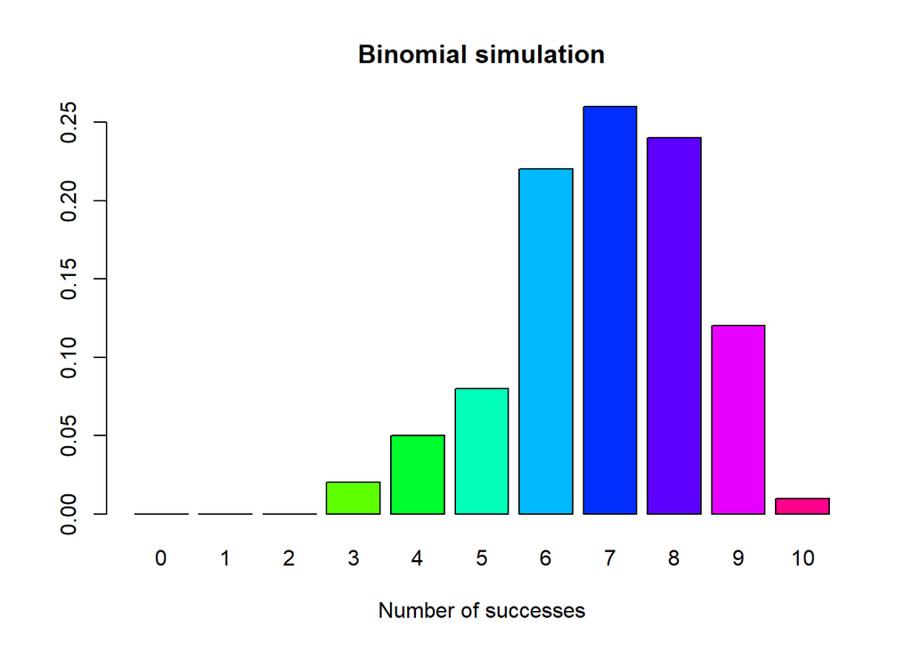

```
##
##    0    1    2    3    4    5    6    7    8    9   10
## 0.00 0.00 0.00 0.02 0.05 0.08 0.22 0.26 0.24 0.12 0.01
```

```r
mybin(iter=100,n=10, p=0.7)
```

## Iterations = 200

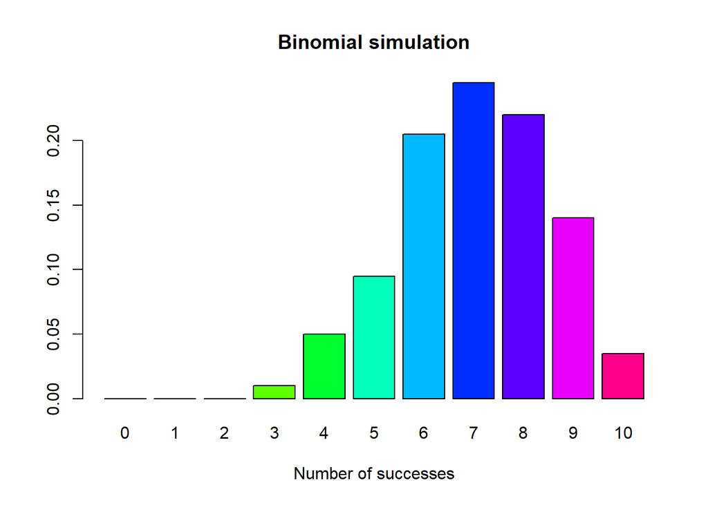

```
##
##     0     1     2     3     4     5     6     7     8     9    10
## 0.000 0.000 0.000 0.010 0.050 0.095 0.205 0.245 0.220 0.140 0.035
```

```r
mybin(iter=200,n=10, p=0.7)
```

## Iterations = 500

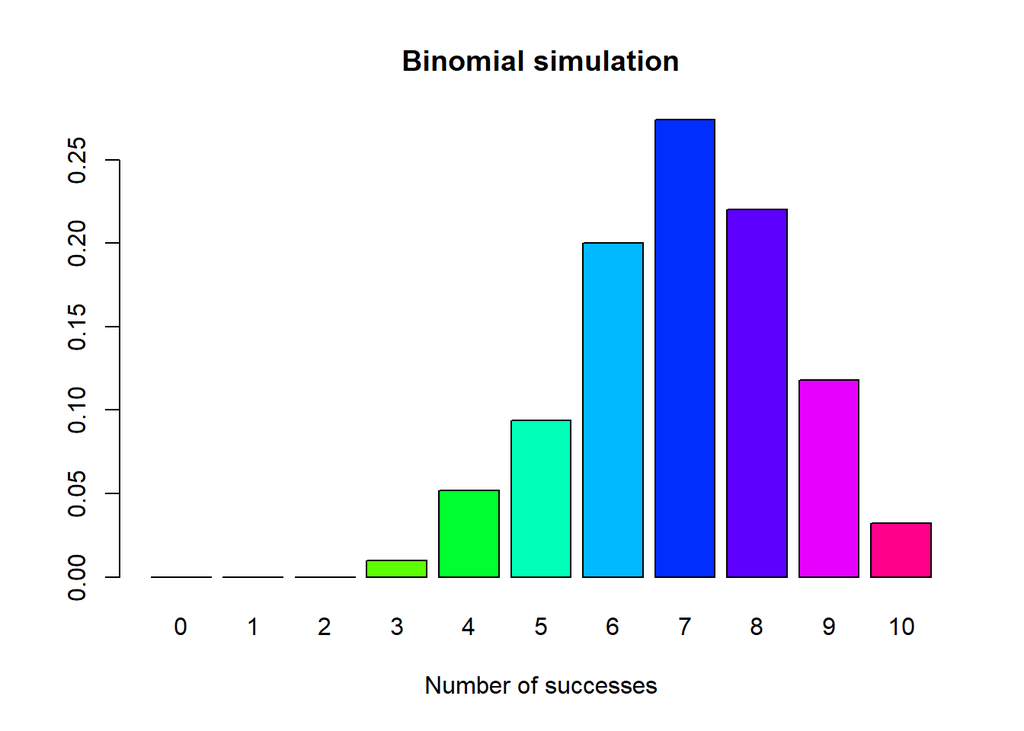

```
##
##     0     1     2     3     4     5     6     7     8     9    10
## 0.000 0.000 0.000 0.010 0.052 0.094 0.200 0.274 0.220 0.118 0.032
```

```r
mybin(iter=500,n=10, p=0.7)
```

## Iterations = 1,000

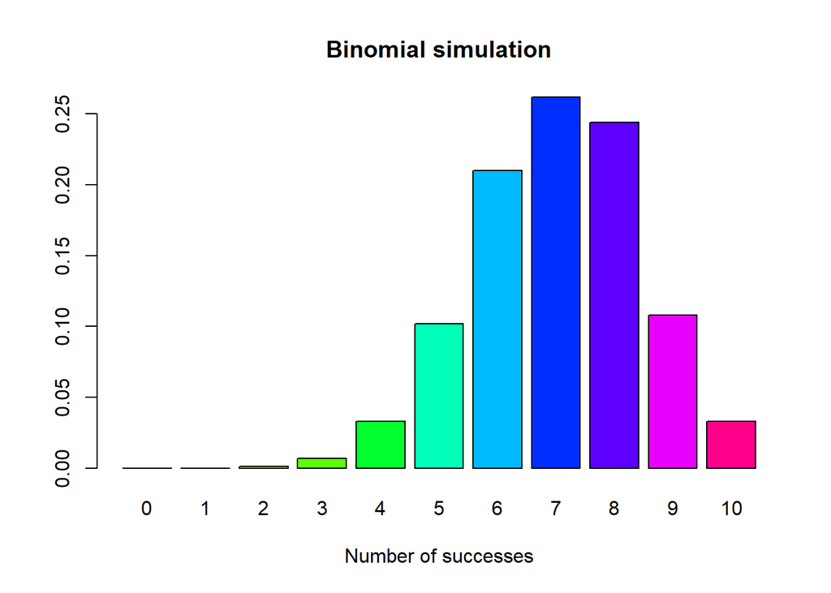

```
##
##     0     1     2     3     4     5     6     7     8     9    10
## 0.000 0.000 0.001 0.007 0.033 0.102 0.210 0.262 0.244 0.108 0.033
```

```r
mybin(iter=1000,n=10, p=0.7)
```

## Iterations = 10,000

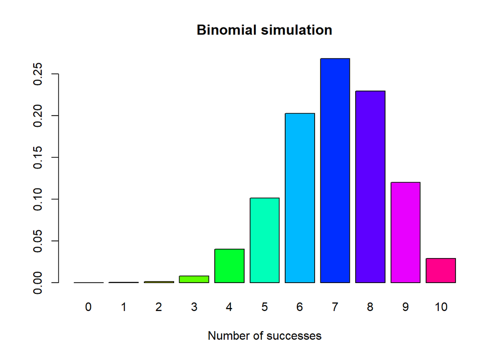

```
##
##      0      1      2      3      4      5      6      7      8      9     10
## 0.0000 0.0001 0.0014 0.0077 0.0399 0.1012 0.2029 0.2685 0.2294 0.1199 0.0290
```

```r
mybin(iter=10000,n=10, p=0.7)
```

## Verifying the 10,000 iteration table:

```r
dbinom(x = 0, size =10, prob = 0.7 )
```

```
## [1] 5.9049e-06
```

```r
dbinom(x = 1, size =10, prob = 0.7 )
```

```
## [1] 0.000137781
```

```r
dbinom(x = 2, size =10, prob = 0.7 )
```

```
## [1] 0.001446701
```

```r
dbinom(x = 3, size =10, prob = 0.7 )
```

```
## [1] 0.009001692
```

```r
dbinom(x = 4, size =10, prob = 0.7 )
```

```
## [1] 0.03675691
```

```r
dbinom(x = 5, size =10, prob = 0.7 )
```

```
## [1] 0.1029193
```

```r
dbinom(x = 6, size =10, prob = 0.7 )
```

```
## [1] 0.2001209
```

```r
dbinom(x = 7, size =10, prob = 0.7 )
```

```
## [1] 0.2668279
```

```r
dbinom(x = 8, size =10, prob = 0.7 )
```

```
## [1] 0.2334744
```

```r
dbinom(x = 9, size =10, prob = 0.7 )
```

```
## [1] 0.1210608
```

```r
dbinom(x = 10, size =10, prob = 0.7 )
```

```
## [1] 0.02824752
```

## Task 2 summary

Comparing results from the 10,000 iteration run of mybin() to that of “dbinom” it can be seen that the values are indeed approximately correct. Assuming we note that $5.9049\times e^{6}$ is approximately zero.

# Task 3

## sample()

There are 20 marbles, population, with $12$ being white and denoted as “1” in the simulation , probability is $\frac{3}{5}$, and $8$ being black denoted as “0” with probability $\frac{2}{5}$.

Thus, we have a sample size of 5 **WITHOUT** replacement:

```r
Marble.bag  <- c(1,1,1,1,1,1,1,1,1,1,1,1,0,0,0,0,0,0,0,0)
Marble.prob <- c(3/5,3/5,3/5,3/5,3/5,3/5,3/5,3/5,3/5,3/5,3/5,3/5,2/5,2/5,2/5,2/5,2/5,2/5,2/5,2/5)
sample(Marble.bag,size=5,prob=Marble.prob, replace=FALSE)
```

```
## [1] 1 1 0 1 1
```

**with**

```r
Marble.bag  <- c(1,1,1,1,1,1,1,1,1,1,1,1,0,0,0,0,0,0,0,0)
Marble.prob <- c(3/5,3/5,3/5,3/5,3/5,3/5,3/5,3/5,3/5,3/5,3/5,3/5,2/5,2/5,2/5,2/5,2/5,2/5,2/5,2/5)
sample(Marble.bag,size=5,prob=Marble.prob, replace=TRUE)
```

```
## [1] 0 1 1 1 1
```

## myhyper()

```r
myhyper=function(iter=100,N=20,r=12,n=5){
# make a matrix to hold the samples
#initially filled with NA's
sam.mat=matrix(NA,nr=n,nc=iter, byrow=TRUE)
#Make a vector to hold the number of successes over the trials
succ=c()
for( i in 1:iter){
#Fill each column with a new sample
sam.mat[,i]=sample(rep(c(1,0),c(r,N-r)),n,replace=FALSE)
#Calculate a statistic from the sample (this case it is the sum)
succ[i]=sum(sam.mat[,i])
}
#Make a table of successes
succ.tab=table(factor(succ,levels=0:n))
#Make a barplot of the proportions
barplot(succ.tab/(iter), col=rainbow(n+1), main="HYPERGEOMETRIC simulation", xlab="Number of successes")
succ.tab/iter
}
# cmd: myhyper(iter=1000,n=19, N=20,r=12)

# cmd: dhyper(x=0:19, m=12, n=8, k=19)
```

## Iterations = 100

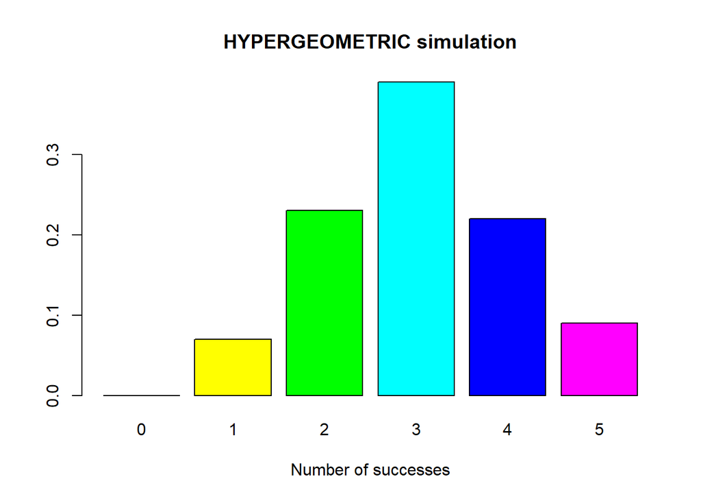

```
##
##    0    1    2    3    4    5
## 0.00 0.07 0.23 0.39 0.22 0.09
```

```r
myhyper(iter=100,n=5,N=20,r=12)
```

## Iterations = 200

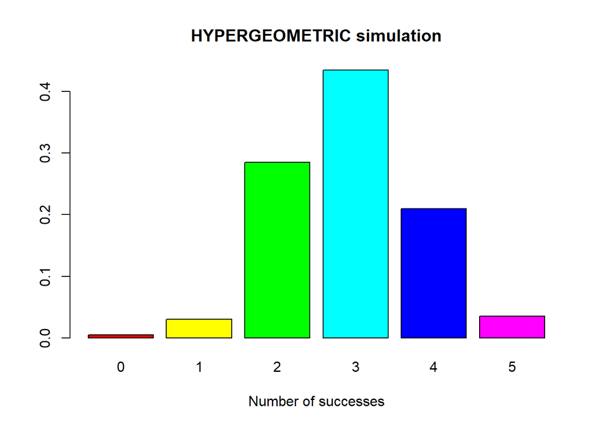

```
##
##     0     1     2     3     4     5
## 0.005 0.030 0.285 0.435 0.210 0.035
```

```r
myhyper(iter=200,n=5,N=20,r=12)
```

## Iterations = 500

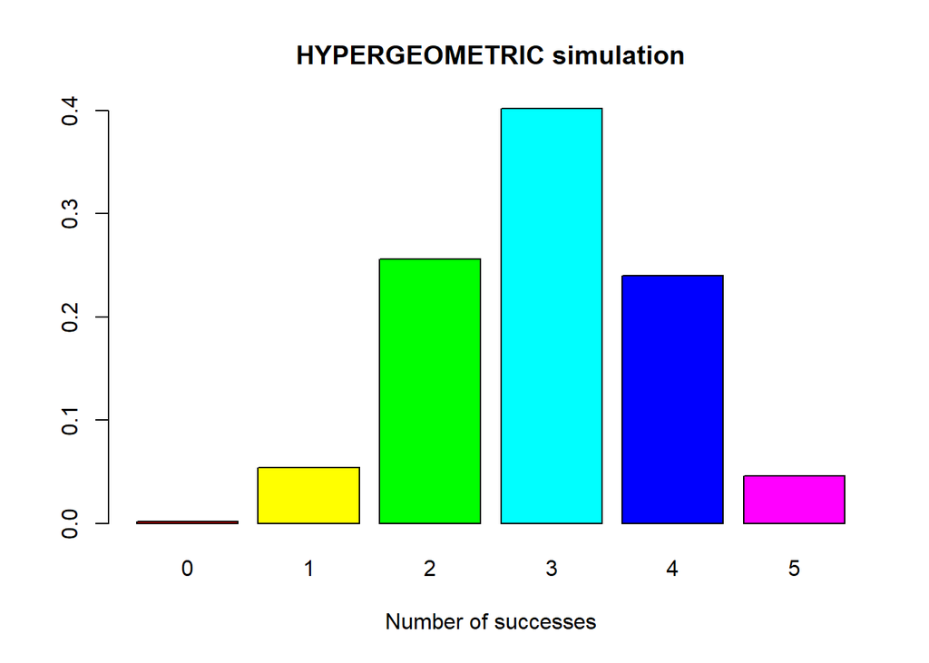

```
##
##     0     1     2     3     4     5
## 0.002 0.054 0.256 0.402 0.240 0.046
```

```r
myhyper(iter=500,n=5,N=20,r=12)
```

## Iterations = 1,000

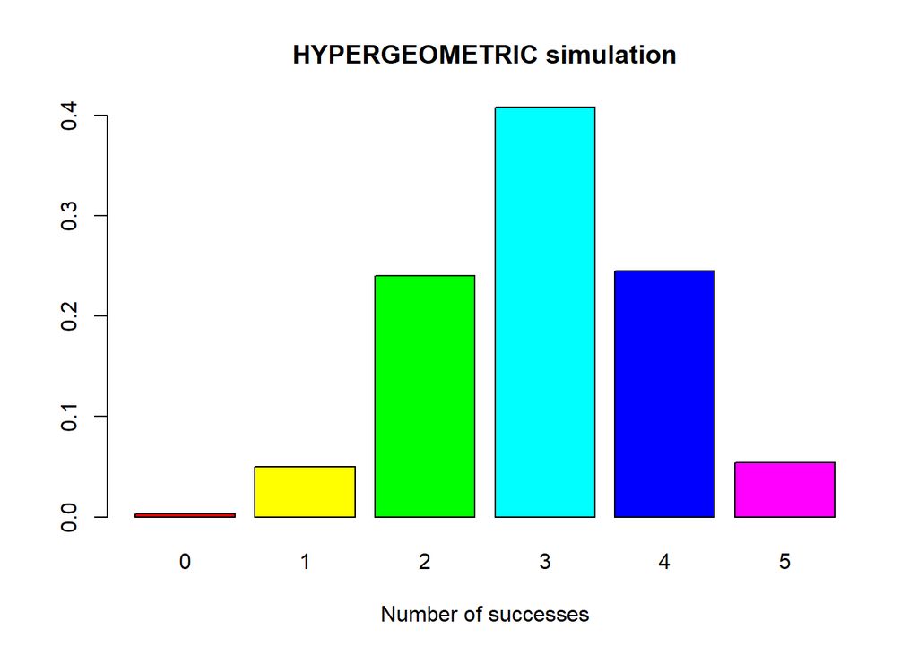

```
##
##     0     1     2     3     4     5
## 0.003 0.050 0.240 0.408 0.245 0.054
```

```r
myhyper(iter=1000,n=5,N=20,r=12)
```

## Iterations = 10,000

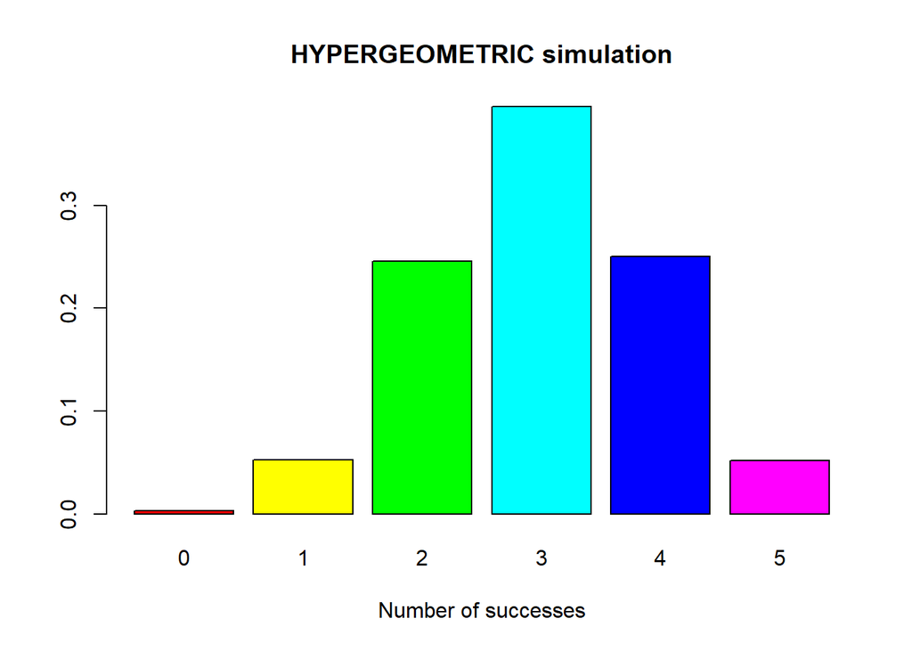

```
##
##      0      1      2      3      4      5
## 0.0033 0.0527 0.2458 0.3963 0.2503 0.0516
```

```r
myhyper(iter=10000,n=5,N=20,r=12)
```

```r
dhyper(x=0:19, m=12, n=8, k=19)
```

```
##  [1] 0.0 0.0 0.0 0.0 0.0 0.0 0.0 0.0 0.0 0.0 0.0 0.6 0.4 0.0 0.0 0.0 0.0 0.0 0.0
## [20] 0.0
```

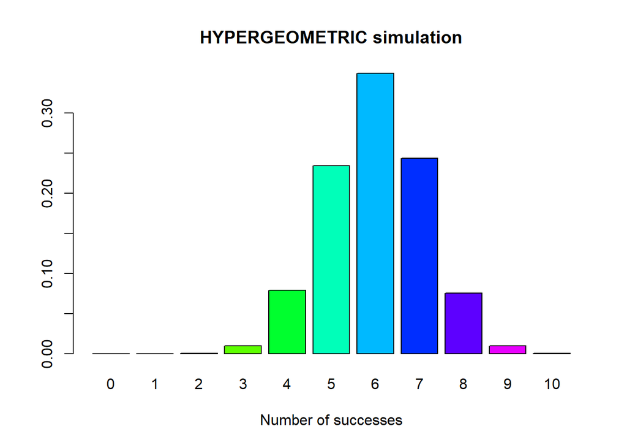

```
##
##      0      1      2      3      4      5      6      7      8      9     10
## 0.0000 0.0000 0.0001 0.0095 0.0787 0.2340 0.3492 0.2434 0.0753 0.0095 0.0003
```

```r
myhyper(iter=10000,n=10,N=20,r=12)
```

# Task 4

[figure not shown]

Running **mysample()** out of R markdown

## What this function does:

This function **mysample()** takes a sample of numbers 1 through 10, with replacement, and creates a new set of probability graphs for each of the 30 iterations.It also slows down the knitting process significantly which is why a screenshot was included of it running in a .R script.

All the graphs are slightly different yet their probabilities for numbers 1 through 10 all center around $0.10$ or it can be seen that all numbers have an almost equal chance of being selected by **mysample()**.

# Task 5

## Bullet 1

```r
choose(8,4)
```

```
## [1] 70
```

This can be verified by the equation:

```r
factorial(8)/(factorial(4)*factorial(4))
```

```
## [1] 70
```

## Bullet 2

```r
1 - dpois(4,lambda = 2)
```

```
## [1] 0.9097765
```

## Bullet 3

```r
mynbin=function(y,r,p){
choose(y-1,r-1)*p^r*(1-p)^(y-r)
}
mynbin(10,3,0.4)
```

```
## [1] 0.06449725
```

## Bullet 4

```r
pbinom(8,15,0.4)
```

```
## [1] 0.9049526
```

# Task 6

```r
MATH4753EvanB::neg.bi.nom(10,3,0.4)
```

```
## [1] 0.06449725
```

# Task 7

My best attempt at **task 7**

```r
neg.binom.sim=function(mu =5, r=100){
  ###
  p = r/mu
  succ = 0
  while(succ<r){
    # Relations
    y= x + r
    q = 1-p
    sigma = sqrt((r*q)/p^2)
    # Probability density
    prob.neg.bi <- choose(y-1,r-1)*p^r*(1-p)^(y-r)
    # Sampling 1's and 0's
    sample.neg<-sample(c(1,0),prob=c(prob.neg.bi,prob.neg.bi),replace=TRUE)
    if (sample.neg == 0){
      x = x + 1
      succ = succ + 1
    }

  }

}
```

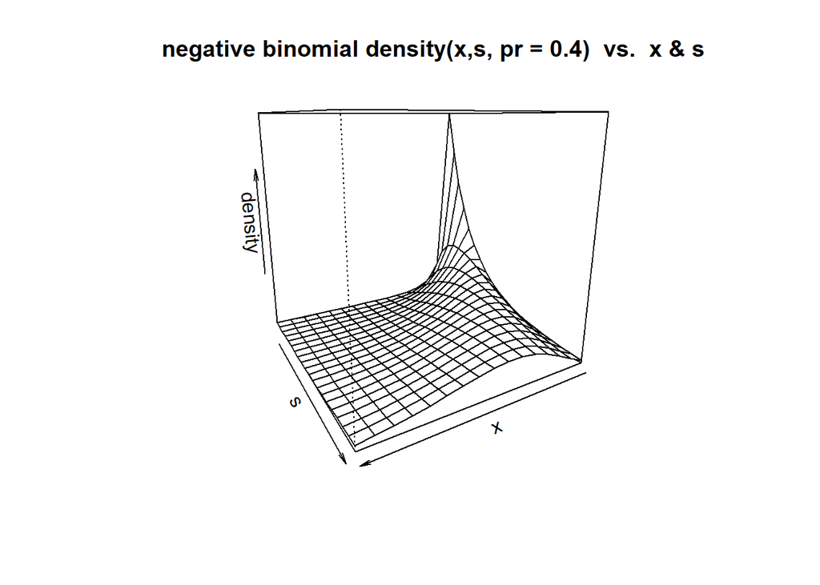

```r
x <- 0:15
size <- (1:20)/4
persp(x, size, dnb <- outer(x, size, function(x,s) dnbinom(x, s, prob = 0.4)),
      xlab = "x", ylab = "s", zlab = "density", theta = 150)
title(tit <- "negative binomial density(x,s, pr = 0.4)  vs.  x & s")
```